# Tidyverse and Data Wrangling

Jeremy Johnson

August 1, 2018

# Reproducible Research using Rmarkdown and the Tidyverse

*Some of the biggest challenges in reproducibility come from **miss-handling** data* This occurs when one or more people modify data, change file names share data that is then modified and analyzed in different ways without proper documentation. Eventually this leads to problems. One of the primary goals of reproducible research is that everyone uses the same data, and nobody modifies data in its native file format. All modification should be conducted in `R` or another environment with all metadata recorded. This is why `Rmarkdown` is so incredibly handy.

Let’s explore how this can be done using an unmodified **WWP** dataset. This data will be used in the afternoon session to conduct a Genome Wide Association Study (GWAS).

## Learning Objectives

- Understand the purpose of `dplyr` and `tidyr`
- Clean an unmodified dataset using `select`, `filter`, `rename`
- Link output from one `dplyr` function and another using “pipe” `%>%` operator
- Create new columns from existing columns using `mutate`
- Summarize data using `summarize`, `goup_by` and `count`
- Plot and explore data using `ggplot2`
- export a data frame to a .txt or .csv file

First we will load the libraries that we need.

```r
#data analysis libraries
library(nlme)
library(dplyr)
```

```r
library(tidyr)
library(ggplot2)
library(GGally)
```

### Import the *Pinus monticola* $\delta$<sup>13</sup>*C* data.

```r
wwp <- read.csv("WWP_phenotype_data_jsj.csv", header = TRUE)
```

Now that we have the data imported into the `R` environment, it’s always good practice to check the data using `str()`, `head()`, and `summary()`

### Tidy the data

Remember the first part of our workflow? After we import the data we want to **tidy** the data.

This includes telling `R` what we want it to do with missing data, changing variable classes (for example from `numeric` to `factor`), making variable names more useful or filtering data out that we do not need.

One problem we have is several records do not actually contain measurements. This is because many seedlings were never planted (`group` 2 intended for planting at a later date) and instead an **NA** was placed as a value in the dataset. Let’s fix this by removing all observations that were never planted (`group`2) using the `filter` function in `dplyr`

```r
#filter out all unplanted records
wwp2 <- filter(wwp, !group %in% c('2'))
```

Now we can use the `select` feature to keep or drop variables. Because right now we are only interested in `population`, `family` and `d13c` we’ll drop `group` and `block`

*In this case it will be easier to drop the unwanted variables instead of keeping the relevant ones. This can be done by placing a `-` in front of the variable name*

```r
#keep only variables that are interesting for this analysis
wwp2 <- select(wwp2, -group, -plot, -block)
```

### Renaming

now that the data is a little bit more tidy we can clean up the variable names. This is done using `rename`

```r
wwp2 <- rename(wwp2, Pop = population, fam = family)
```

### Using `mutate` to create a new column

Sometimes we need to create new columns based on analysis or summary data from current columns. `dplyr` has the `mutate` function that allows us to do this. For example, if we want to create a new column that has a binary variable (categorical) if $\delta$<sup>13</sup>*C* is less than -30 using `mutate`.

```r
wwp2.d13c <- mutate(wwp2, low.d13c = ifelse(d13c <= -30.00, 1, 0))
```

This is interesting, but because each seedling is an open pollinated member of a family (seed source) growing in a progeny array in our common gardens it may be more useful to know the mean $\delta$<sup>13</sup>*C* by either family or population.

Use `group_by` to group observations together; we’ll `group_by` `fam`. `fam` is the identifier of the seed source tree where seeds were collected from.

```r
wwp.fam <- group_by(wwp2.d13c, fam)
wwp.fam
```

```
## # A tibble: 779 x 4
## # Groups:   fam [157]
##    Pop       fam  d13c low.d13c
##    <fct>   <int> <dbl>    <dbl>
##  1 blk cyn    59 -30.2       1.
##  2 blk cyn    59 -29.7       0.
##  3 blk cyn    59 -29.6       0.
##  4 blk cyn    59 -29.2       0.
##  5 blk cyn    59 -29.0       0.
##  6 blk cyn    60 -31.2       1.
##  7 blk cyn    60 -30.7       1.
##  8 blk cyn    60 -30.5       1.
##  9 blk cyn    60 -30.1       1.
## 10 blk cyn    60 -29.3       0.
## # ... with 769 more rows
```

Now the data is all still there but you will notice that a grouping variable is included.

```r
wwp.fam.mean <- summarize(wwp.fam, count = n(), mean.d13c = mean(d13c, na.rm = TRUE))

wwp.fam.mean
```

```
## # A tibble: 157 x 3
##      fam count mean.d13c
##    <int> <int>     <dbl>
##  1    59     5     -29.5
##  2    60     5     -30.4
##  3    61     5     -30.3
##  4    63     5     -31.0
##  5    64     5     -30.0
##  6    65     5     -30.7
##  7    67     5     -30.3
##  8    69     5     -30.3
##  9    72     5     -29.4
## 10    73     3     -29.0
## # ... with 147 more rows
```

### combining the $\delta$<sup>13</sup>*C* dataset with *environmental* data

Now that we have mean $\delta$<sup>13</sup>*C* for 157 families of *P. monticola* we want to see if there is any relationship with environmental factors. Luckily we have a dataset that has the environmental data and we need to import it into `R`

```r
wwp.env <- read.csv("WWP_environmental_data.csv", header = TRUE)
```

Again, let’s check the data using `str()`, `head()`, and `summary()`

It looks good. For the sake of consistency let’s also `rename` `family` to `fam` to match our phenotype data and generate our `key attribute`.

```r
wwp.env <- rename(wwp.env, fam = family)
```

now lets add our mean $\delta$<sup>13</sup>*C*

```r
wwp.d13c.env <- left_join(wwp.env, wwp.fam.mean, by = c('fam'))
```

double check the new data frame `str()`

Great! We’ve combined the two data frames and can now look at some of the environmental relationships.

### Visualize using `ggplot2`

With our data a bit cleaner we can visualize our mean $\delta$<sup>13</sup>*C* relative to the latitude of our populations. We can also include the best fit line. In this case I’m using a linear model, but other models can be used (and may be more appropriate).

Lets first drop `count` from this dataset and look at the correlations between all variables and plot it as a heat map using `ggcorr`. This is a nice first pass at relationships

```r
#drop count
wwp.d13c.env <- select(wwp.d13c.env, -count)
```

Now we will plot the `pearson` `pairwise` correlation coefficients using `ggcorr`

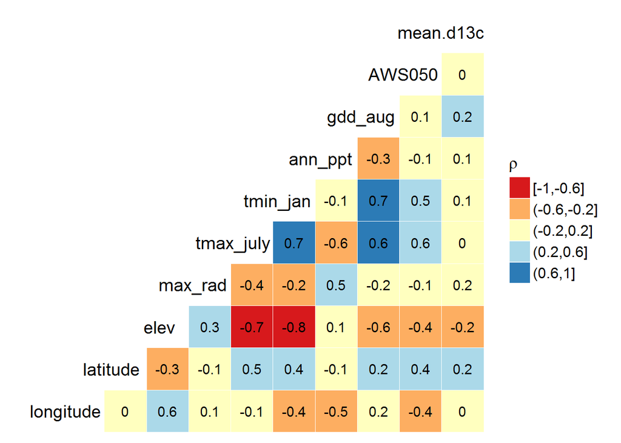

```r
#plot correlation and drop population and fam from heat map

ggcorr(wwp.d13c.env[3:12], nbreaks = 5, palette = "RdYlBu", name = expression(rho), label = TRUE, hjust = 0.75, size = 5, layout.exp = 1, legend.position = "right", legend.size = 12) +
  theme(legend.title = element_text(size = 14))
```

```r
# could also use circles - geom = "circle", nbreaks = 5
```

Our correlation heat map shows that $\delta$<sup>13</sup>*C* is most negatively correlated with **elevation** and most positively correlated with **latitude** (*also tied with August growing degree days*).

Lets plot these relationships using a linear best fit.

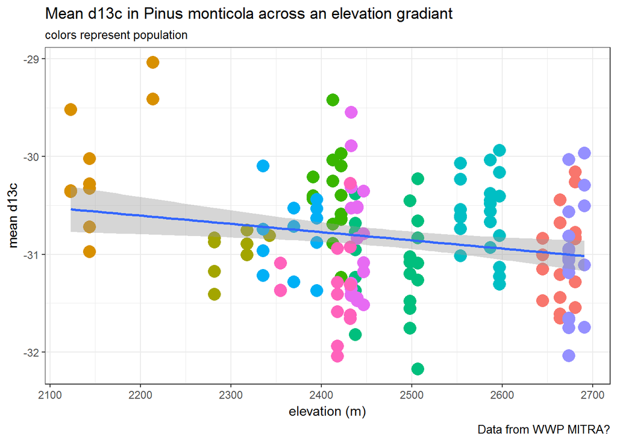

```r
#Elevation

wwp.d13c.env %>%
  ggplot(aes(elev, mean.d13c)) +
  geom_point(aes(color = population, size = 1.5)) +
  geom_smooth(method = 'lm', se = T) +
  #geom_label(aes(label = population), nudge_y = 1, alpha = 0.5) +
  labs(
    title = "Mean d13c in Pinus monticola across an elevation gradiant",
    subtitle = "colors represent population",
    caption = "Data from WWP MITRA?"
  ) +
    labs(x = "elevation (m)") +
  labs(y = "mean d13c") +
  theme_bw() + theme(legend.position = "none")
```

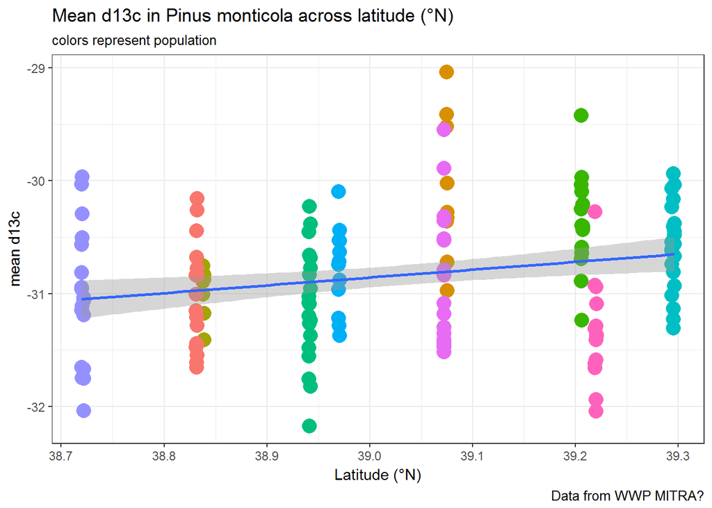

```r
#Latitude

wwp.d13c.env %>%
  ggplot(aes(latitude, mean.d13c)) +
  geom_point(aes(color = population, size = 1.5)) +
  geom_smooth(method = 'lm', se = T) +
  #geom_label(aes(label = population), nudge_y = 1, alpha = 0.5) +
  labs(
    title = "Mean d13c in Pinus monticola across latitude (°N)",
    subtitle = "colors represent population",
    caption = "Data from WWP MITRA?"
  ) +
    labs(x = "Latitude (°N)") +
  labs(y = "mean d13c") +
  theme_bw() + theme(legend.position = "none")
```

However, let’s test to see if these relationships are significant.

### Model

Now that we have explored and visualized our data, we can test the hypothesis that the $\delta$<sup>13</sup>*C* at our common gardens are related to seed source latitude and elevation.

We’ll use a linear mixed model to account for population as a random factor and capture some of the nested design from the progeny array.

```r
d13c.lat <- lme(mean.d13c ~ latitude, random =  ~ 1|population, data = wwp.d13c.env)

summary(d13c.lat)
```

```
## Linear mixed-effects model fit by REML
##  Data: wwp.d13c.env
##        AIC      BIC    logLik
##   244.2326 256.4063 -118.1163
##
## Random effects:
##  Formula: ~1 | population
##         (Intercept)  Residual
## StdDev:   0.3352981 0.4803732
##
## Fixed effects: mean.d13c ~ latitude
##                 Value Std.Error  DF   t-value p-value
## (Intercept) -56.74366  24.43871 146 -2.321876  0.0216
## latitude      0.66440   0.62633 146  1.060780  0.2905
##  Correlation:
##          (Intr)
## latitude -1
##
## Standardized Within-Group Residuals:
##         Min          Q1         Med          Q3         Max
## -2.27413214 -0.68502152 -0.01190278  0.55345812  2.71327369
##
## Number of Observations: 157
## Number of Groups: 10
```

```r
d13c.elev <- lme(mean.d13c ~ elev, random =  ~ 1|population, data = wwp.d13c.env)

summary(d13c.elev)
```

```
## Linear mixed-effects model fit by REML
##  Data: wwp.d13c.env
##        AIC      BIC    logLik
##   258.1022 270.2759 -125.0511
##
## Random effects:
##  Formula: ~1 | population
##         (Intercept)  Residual
## StdDev:   0.3182047 0.4819655
##
## Fixed effects: mean.d13c ~ elev
##                  Value Std.Error  DF    t-value p-value
## (Intercept) -29.183479 1.6241218 146 -17.968775  0.0000
## elev         -0.000667 0.0006604 146  -1.009993  0.3142
##  Correlation:
##      (Intr)
## elev -0.998
##
## Standardized Within-Group Residuals:
##          Min           Q1          Med           Q3          Max
## -2.240775876 -0.666981261 -0.006557072  0.546632139  2.700607350
##
## Number of Observations: 157
## Number of Groups: 10
```

There is much more that can be done. At this point it may be good to output your data as a new data file so that it can be used later.

### Export data as `.txt` file for later

```r
write.table(wwp.d13c.env, "wwp.d13c.env.txt", sep="\t")
```

## Communicate

At this point maybe new hypothesis have been generated or new experiments need to be conducted. The final step in the workflow is to communicate your results. We generally do this through scientific publications and meetings. The nice thing about Rmarkdown is that it can easily be archived and the data, annotated readable code, and analysis pipeline can be shared freely.

This example is certainly not exhaustive. I hope what you really see is not the analysis, but the potential and utility of using `Rmarkdown` to generate a readable document that allows you to replicate your analysis, pass it on to others, and as I’ll show next, collaborate.